# Mitochondial mutational spectrum of cancer as a function of position, tissue and VAF

Konstantin Popadin

11/05/2022

## Background

Cancer paper: Dataset is 7611 somatic mtDNA mutations  
Hypothesis: A>G is a function of TBSS, TissueTurnOver and VAF

#### 1. Read a cancer dataset and describe key variables

```r
Mut = read.table("../data/1raw/mtDNA_snv_Oct2016.txt", head = TRUE, sep = '\t')
names(Mut)
```

```
##  [1] "index"                    "is_blacklist_removed"
##  [3] "is_included_in_may_pilot" "sample"
##  [5] "tissue"                   "Tier2"
##  [7] "chrom"                    "position"
##  [9] "ref"                      "var"
## [11] "normal_reads1"            "normal_reads2"
## [13] "normal_var_freq"          "normal_gt"
## [15] "tumor_reads1"             "tumor_reads2"
## [17] "tumor_var_freq"           "outlier_mismatchnum"
## [19] "outlier_n_VAF"            "was_filtered"
## [21] "sample_included"          "index.1"
## [23] "sample.1"                 "tissue.1"
## [25] "chrom.1"                  "position.1"
## [27] "ref.1"                    "var.1"
## [29] "mtDB"                     "mtDB_freq"
## [31] "Levin2012"                "Annot"
## [33] "Nearest_5p"               "Nearest_3p"
## [35] "X"                        "X.1"
## [37] "X.2"                      "X.3"
## [39] "variant_p_value"          "somatic_p_value"
## [41] "tumor_reads1_plus"        "tumor_reads1_minus"
## [43] "tumor_reads2_plus"        "tumor_reads2_minus"
## [45] "normal_reads1_plus"       "normal_reads1_minus"
## [47] "normal_reads2_plus"       "normal_reads2_minus"
## [49] "pval"                     "is_nonsense"
## [51] "is_missense"              "is_silent"
## [53] "is_tRNA"
```

```r
Mut$Subst = paste(Mut$ref,Mut$var,sep = '>')
table(Mut$Subst) # light chain notation is be default
```

```
##
##  A>C  A>G  A>T  C>A  C>G  C>T  G>A  G>C  G>T  T>A  T>C  T>G
##   91  481   72  167   22  771 3663  119   49   29 2120   27
```

```r
table(Mut$Tier2) # cancer tissue
```

```
##
##         Biliary         Bladder Bone/SoftTissue          Breast          Cervix
##              90              99             155             689              38
##             CNS    Colon/Rectum       Esophagus       Head/Neck          Kidney
##             262             224             409             146             822
##           Liver            Lung        Lymphoid         Myeloid           Ovary
##            1273             268             316              78             402
##        Pancreas        Prostate            Skin         Stomach         Thyroid
##             861             739             217             210             168
##          Uterus
##             145
```

```r
Mut$tumor_var_freq = as.numeric(gsub('%','',Mut$tumor_var_freq))
summary(Mut$tumor_var_freq)
```

```
##    Min. 1st Qu.  Median    Mean 3rd Qu.    Max.
##    0.01    1.68    4.37   19.96   25.39   99.86
```

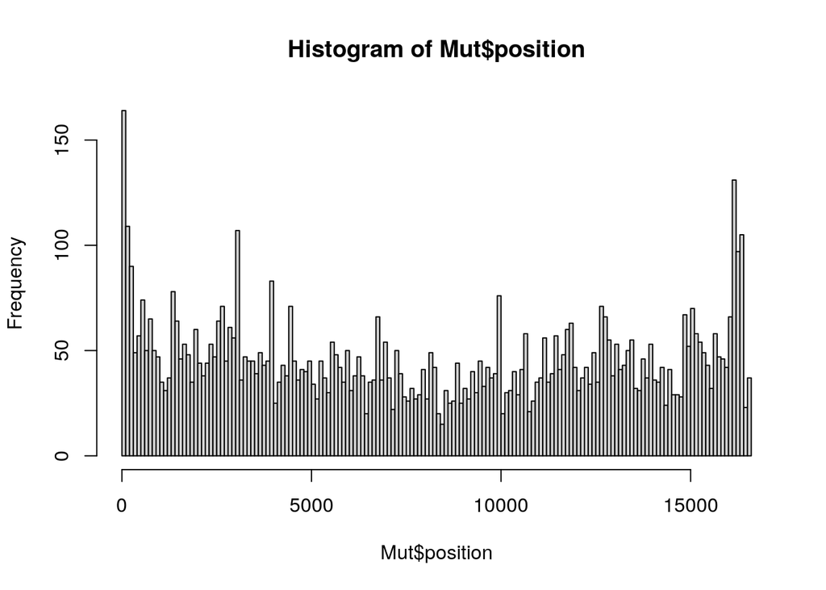

```r
hist(Mut$position, breaks = 200)
```

There are many mutations from D loop [16024 - 576 according to MitoWheel]. Since they mutate according to different rules, it is better to delete all of them in the analyses. In this case for all other mutations we can derive time being single stranded.

#### 2. Create a dataset with tissue-specific turnover rates and merge it to the Mut

```r
CancerTissue = c('Bladder','Bone/SoftTissue','Breast','Biliary','Cervix','Lymphoid','Myeloid','Colon/Rectum','Prostate','Esophagus','Stomach','CNS','Head/Neck','Kidney','Liver','Lung','Ovary','Pancreas','Skin','Thyroid','Uterus')
TurnOverDays = c(200,5373,84.5,200,6,30,30,5,120,11,5.5,10000,16,1000,400,5143,11000,360,147,4138,4); length(TurnOverDays)
```

```
## [1] 21
```

```r
Turn = data.frame(CancerTissue,TurnOverDays)
Turn = Turn[order(Turn$TurnOverDays),]
summary(Turn$TurnOverDays)
```

```
##    Min. 1st Qu.  Median    Mean 3rd Qu.    Max.
##       4      16     147    1823    1000   11000
```

```r
Turn$DummyNotFastTurnOver = 0;
Turn$DummySlowTurnOver = 0;
Turn$DummyVerySlowTurnOver = 0;
for (i in 1:nrow(Turn))
{
if (Turn$TurnOverDays[i] > 1000) {Turn$DummyVerySlowTurnOver[i] = 1} # if  slower than the third quartile (1000 days)
if (Turn$TurnOverDays[i] > 147)  {Turn$DummySlowTurnOver[i] = 1}  # if  slower than the median (147 days)
if (Turn$TurnOverDays[i] > 16)  {Turn$DummyNotFastTurnOver[i] = 1}  # if  slower than the median (147 days)
}

Turn
```

```
##       CancerTissue TurnOverDays DummyNotFastTurnOver DummySlowTurnOver
## 21          Uterus          4.0                    0                 0
## 8     Colon/Rectum          5.0                    0                 0
## 11         Stomach          5.5                    0                 0
## 5           Cervix          6.0                    0                 0
## 10       Esophagus         11.0                    0                 0
## 13       Head/Neck         16.0                    0                 0
## 6         Lymphoid         30.0                    1                 0
## 7          Myeloid         30.0                    1                 0
## 3           Breast         84.5                    1                 0
## 9         Prostate        120.0                    1                 0
## 19            Skin        147.0                    1                 0
## 1          Bladder        200.0                    1                 1
## 4          Biliary        200.0                    1                 1
## 18        Pancreas        360.0                    1                 1
```

[output cut: 29 more lines]

```r
Mut = merge(Mut,Turn, by.x = 'Tier2', by.y = 'CancerTissue')
summary(Mut$TurnOverDays) # there are no NA - good
```

```
##    Min. 1st Qu.  Median    Mean 3rd Qu.    Max.
##     4.0    84.5   360.0  1554.0  1000.0 11000.0
```

#### 3. Derive TBSS for each position, positions within D-loop and Ol will have NA

```r
Mut$TBSS = NA
for (i in 1:nrow(Mut))
{ # i = 1
  if (Mut$position[i] > 576 & Mut$position[i] < 5721) # minor arc
    {Mut$TBSS[i] = 16569-(5721 - Mut$position[i])*2} # L-strand replication origin (locus MT-OLR, 5721 - 5798)
  if (Mut$position[i] > 5798 & Mut$position[i] < 16024) # major arc
    {Mut$TBSS[i] = (Mut$position[i] - 5798)*2}
}
summary(Mut$TBSS)
```

```
##    Min. 1st Qu.  Median    Mean 3rd Qu.    Max.    NA's
##       6    7659   11189   10959   14679   20450    1016
```

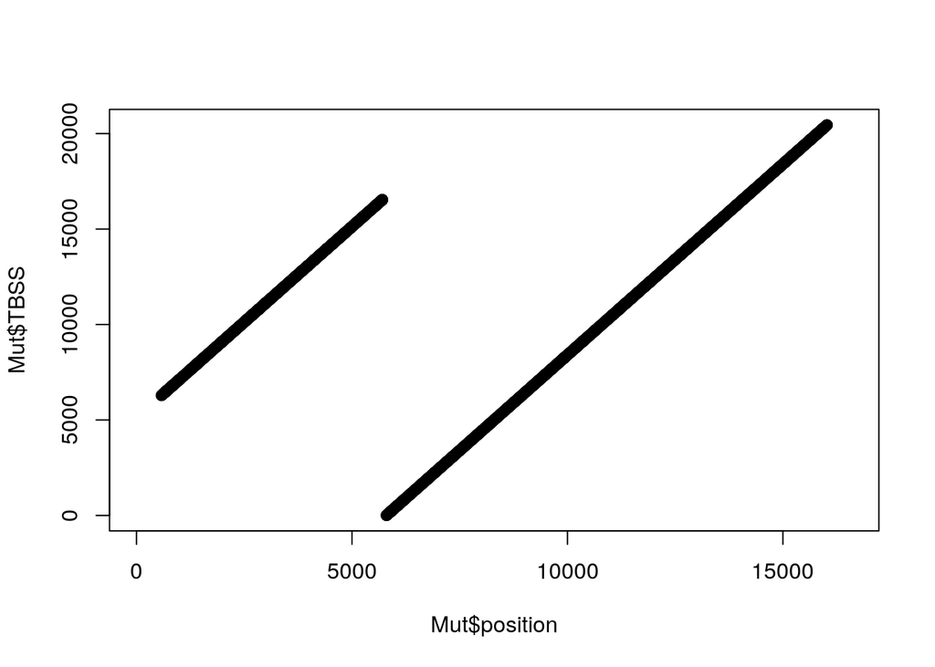

```r
plot(Mut$position,Mut$TBSS)
```

### 4. add several dummy variables for logistic regression: Ah>Gh, Ch>Th, Ts, Tv

```r
Mut$DummyAhGh = 0; Mut$DummyChTh = 0; Mut$DummyTs = 0; Mut$DummyTv = 0;
for (i in 1:nrow(Mut))
{ # i=1
  if (Mut$Subst[i] == 'T>C') {Mut$DummyAhGh[i] = 1}
  if (Mut$Subst[i] == 'G>A') {Mut$DummyChTh[i] = 1}
  if (Mut$Subst[i] %in% c('G>A','T>C','C>T','A>G')) {Mut$DummyTs[i] = 1}
  if (!Mut$Subst[i] %in% c('G>A','T>C','C>T','A>G')) {Mut$DummyTv[i] = 1}
}
table(Mut$DummyAhGh)
```

```
##
##    0    1
## 5491 2120
```

```r
table(Mut$DummyChTh)
```

```
##
##    0    1
## 3948 3663
```

```r
table(Mut$DummyTs)
```

```
##
##    0    1
##  576 7035
```

```r
table(Mut$DummyTv)
```

```
##
##    0    1
## 7035  576
```